# Gross Domestic Inequality

Income Distribution Improvement Opportunities

Pawel Rzeczkowski

2023-02-04

# Abstract

The Western World countries are generally considered to be industrialized, capitalist, and democratic, and they tend to have a high standard of living. They tend to have a liberal economic system, and they have a tradition of individual rights, freedom of speech, and rule of law. In other words, those are countries that share certain cultural, political, and economic characteristics.

There is one country that stands out. That country ranks No 1 in this category! Most of the time this would be admirable. Unfortunately, I am referring to the Gini Index, a measure of income inequality. Most western world countries Gini Index ranges from high 20’s to low or mid 30’s. The USA, however, is on par with income inequality in Mexico, Bolivia, Argentina, or Peru which is to say low 40’s.

In this analysis, I will look at income from 30,000 feet to see if there are opportunities to make things more accessible for more people.

This analysis will use the twin of Gross Domestic Product (GDP), the most famous economic indicator, to illustrate that public access to income is full of inaccessible high curbs and barriers most people are not capable of stepping over. The twin metrics in question is **Gross Domestic Income (GDI)**.

Both GDP and GDI measure the total economic activity in a country. Although different, they are related. The GDP measures the total value of goods and services produced, while the GDI measures the total income earned by residents. When consumers are spending money on the finished goods and services, the P in GDP, that spending is received by someone else as income, the I in GDI.

GDI is a more comprehensive measure of income and can provide a better measure of living standards. In practice, GDP and GDI are usually very close to each other and tend to move in tandem.

Looking at the factors that make up GDI presents an opportunity to understand and address income inequality in a more comprehensive way.

# Support

The Federal Reserve Bank of St. Louis is one of 12 regional banks that make up the Federal Reserve System, which is the central banking system of the United States. One of the main functions of the Federal Reserve Bank of St. Louis is to conduct economic research and provide data and analysis on the economy. The bank has made a significant amount of this data available to the public through its website, including through a tool called FRED (Federal Reserve Economic Data). [FRED is a widely used and well-regarded source of economic data, including data on GDP and GDI, and is the source of our data.](https://fred.stlouisfed.org/release/tables?rid=53&eid=42185#)

The link above will get you to the annual data table of FED Gross Domestic Income by Type of Income. This is exactly what we want. Click on “Add to my List.”

To be able to create a data list and to download all the GDI components you need to create a free account with the St. Louis Fed. It is worth it as their data is fascinating and you will find yourself coming back to this wonderful source.

Here are the steps to get the data:

#### Step 1 - Add to My List

We are told that GDI is made up of 24 components. We ignore all the calculations and data range options on this page as we only want the raw data. At the bottom of page click “Add Series to my Data List.”

#### Step 2 - Data List - Components of GDI

You have an option here to exclude some of the data series that make up GDI. Ignore it. keep all the series. Click “download.”

#### Step 3 - Download Data

You have a choice to define your observation range. I leave the default - from 1929 to 2021 You have a choice of format, Excel, or Tab Delimited Text file. I choose: the Tab Delaminated Text File and I download the file.

Save the file to your desired location.

# Process

With data from FRED there is not much data cleaning required as there is understanding the data. Fundamentally, what we downloaded is the detail for adding up employee compensation, rent, interest, and profit. What are the 24 data series? Well, there is accounting and sources of data to consider, as well as, how to handle taxes.

I will try to stay clear of the accounting detail and keep the analysis at 30,000 feet.

Some data processing is required. Alphanumeric Series IDs are used as the column headings. To understand what we are looking at, we need to reference the accompanying ReadMe file for column titles.

The GDI Data series contains 7 subtotals, 15 input numbers, 1 statistical data point, and the date series. Feel free to [download my Excel file](https://eternalspring22.github.io/Rzeczkowski.github.io/GDI.xlsx) to understand how the data rolls up to GDI.

To get started with R we load the packages we need to do the analysis, ‘tidyverse’, ‘scales’, ‘ggthemes’.

```r
install.packages("tidyverse", repos = "http://cran.us.r-project.org")
library(tidyverse)
```

```r
install.packages("ggplot2", repos = "http://cran.us.r-project.org")
library("ggplot2")

install.packages("ggthemes", repos = "http://cran.us.r-project.org")
library(ggthemes)

install.packages("scales", repos = "http://cran.us.r-project.org")
library(scales)
install.packages("data.tables", repos = "http://cran.us.r-project.org")
library(data.table)
```

Import the text file you downloaded from FRED and load the Components_of_GDI_Annual table as GDI.

```r
GDI <- read.table("/Users/pawelrzeczkowski/Google Drive/Goggle Certificate/Portfolio Projects/GDI_components/Components_of_GDI_Annual.txt",
                      header=TRUE, sep="\t", fileEncoding = "UTF-8")
GDI$observation_date <- as.Date(GDI$observation_date, format = "%Y-%m-%d")
```

The column headers in the table are the U.S. Bureau of Economic Analysis Series IDs. Based on the ReadMe file I change the column titles I intend to use into meaningful names to improve data usability.

```r
colnames(GDI)[colnames(GDI) == "A449RC1A027NBEA"] <- "Dividents"
colnames(GDI)[colnames(GDI) == "A024RC1A027NBEA"] <- "Depreciation"
colnames(GDI)[colnames(GDI) == "W274RC1A027NBEA"] <- "Retained_Earnings"
colnames(GDI)[colnames(GDI) == "W272RC1A027NBEA"] <- "Interest_Loans_Bonds"
colnames(GDI)[colnames(GDI) == "A041RC1A027NBEA"] <- "Sole_Proprietorships"
colnames(GDI)[colnames(GDI) == "A048RC1A027NBEA"] <- "Rental_Income"
colnames(GDI)[colnames(GDI) == "GDINOSA"] <- "Business_Income"
colnames(GDI)[colnames(GDI) == "A4102C1A027NBEA"] <- "Wages"
colnames(GDI)[colnames(GDI) == "A038RC1A027NBEA"] <- "Bonuses_Benefits"
colnames(GDI)[colnames(GDI) == "GDICOMPA"] <- "Total_Compensation"
colnames(GDI)[colnames(GDI) == "GDIA"] <- "GDI"
```

The data series we use here reflects nominal GDI numbers. An alternative would have been to use real GDI, adjusted for inflation. I chose to use the nominal numbers as this analysis focuses on relative position of line items within the GDI metric as opposed to the year over year growth of the metric that is the focus of most investors.

Economic growth reflected in real DGI or GDP numbers may lead to an overall increase in wealth, although it will not necessarily lead to a more equitable social structure.

The relative position of the metrics gives insight into social structures reflected in the numbers. A constant relationship might reflect those at the top of the economic ladder continuing to hold a disproportionate share of wealth and resources, while those at the bottom continue to have limited access to opportunities and resources. Without understanding the structural limitations, it is difficult to innovate or propose solutions.

Let us calculate the relative positioning of various key GDI component metrics versus each other. This is the crux of this analysis.

```r
GDI$Wage_GDI <- with(GDI, Wages/GDI)
GDI$Business_GDI <- with(GDI, Business_Income/GDI)
GDI$Bonuses_GDI <- with(GDI, Bonuses_Benefits/GDI)
GDI$Compensation_GDI <- with(GDI, Total_Compensation/GDI)
GDI$NonComp_GDI <- with(GDI, (GDI-Total_Compensation)/GDI)
GDI$Dividents_BIZ <- with(GDI, Dividents/Business_Income)
GDI$Retained_Earnings_BIZ <- with(GDI, Retained_Earnings/Business_Income)
GDI$Interest_Income_BIZ <- with(GDI, Interest_Loans_Bonds/Business_Income)
GDI$Rentals_BIZ <- with(GDI, Rental_Income/Business_Income)
GDI$SmallBusiness_BIZ <- with(GDI, Sole_Proprietorships/Business_Income)
```

Diving into the data is exciting, as you might find hope where others see a steep wall of hopelessness.

# Analysis

Income inequality is often associated with labor market dynamics, such as wages, benefits, and working conditions, which are directly related to labor income. Ask Alexa to play the news and you might learn about one million French workers marching in the streets protesting raising the retirement age or about Minneapolis Public School teachers’ union walking out in support of education support professionals. Workers, labor, pay are the refrains that pop into people’s minds when you mention inequality.

Income inequality is a tangible and measurable form of inequality, widely discussed in the media and in public policy. Who has not heard about income inequality in context of race or gender. It is relatable as most everybody works. Every quarter the markets go up and down with the Bureau of Labor Statistics release of employment and unemployment data.

However, when you look at 93 years of data on Gross Domestic Income, something peculiar jumps out. Only about half of the aggregate income is derived from labor. [The St. Louis FED identifies 15 recessions in the 93 years of this data.](https://fred.stlouisfed.org/series/A024RC1A027NBEA) The markets have grown, fortunes were made and lost, wars were fought, the world changed. Yet somehow the relationship of income derived from labor and other forms of income held relatively steady at around 50/50 split. Toss of a coin? Or rigid social structure? How come we only talk about half the income?

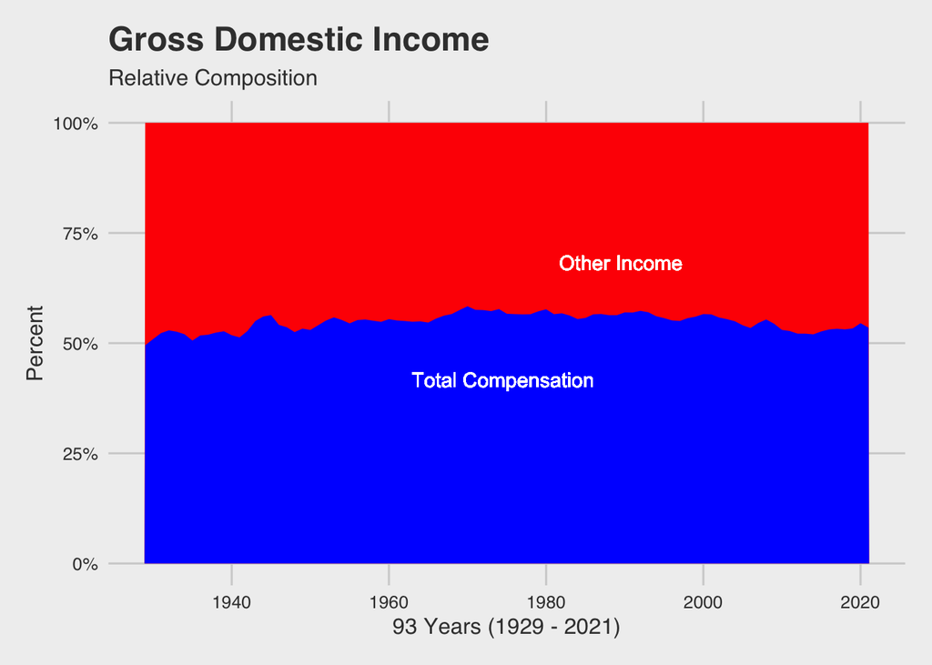

```r
ggplot(GDI, aes(x = observation_date)) +
  geom_area(aes(y = GDI/GDI, fill="red")) + #Non Compensation Income
  geom_area(aes(y = Total_Compensation/GDI, fill="blue"), position = "stack") +
  geom_text(aes(label = "Total Compensation", x = max(observation_date), y = .5), hjust = 2.5, vjust = 3, color = "white") +
  geom_text(aes(label = "Other Income", x = max(observation_date), y = .5), hjust = 2.5, vjust = -5, color = "white") +
  scale_fill_manual(values=c('blue', 'red')) +
  guides(fill="none") +
  labs(title = "Gross Domestic Income",
       subtitle = "Relative Composition",
       x = "93 Years (1929 - 2021)",
       y = "Percent") + #Percent of Gross Domestic Income
  theme_fivethirtyeight() +
  theme(axis.title = element_text()) +
  scale_y_continuous(labels=scales::percent)
```

If we break out the supplements to wages and salaries from the total compensation, the wages by themselves drop over the past decade to 42-44% of the total Gross Domestic Income.

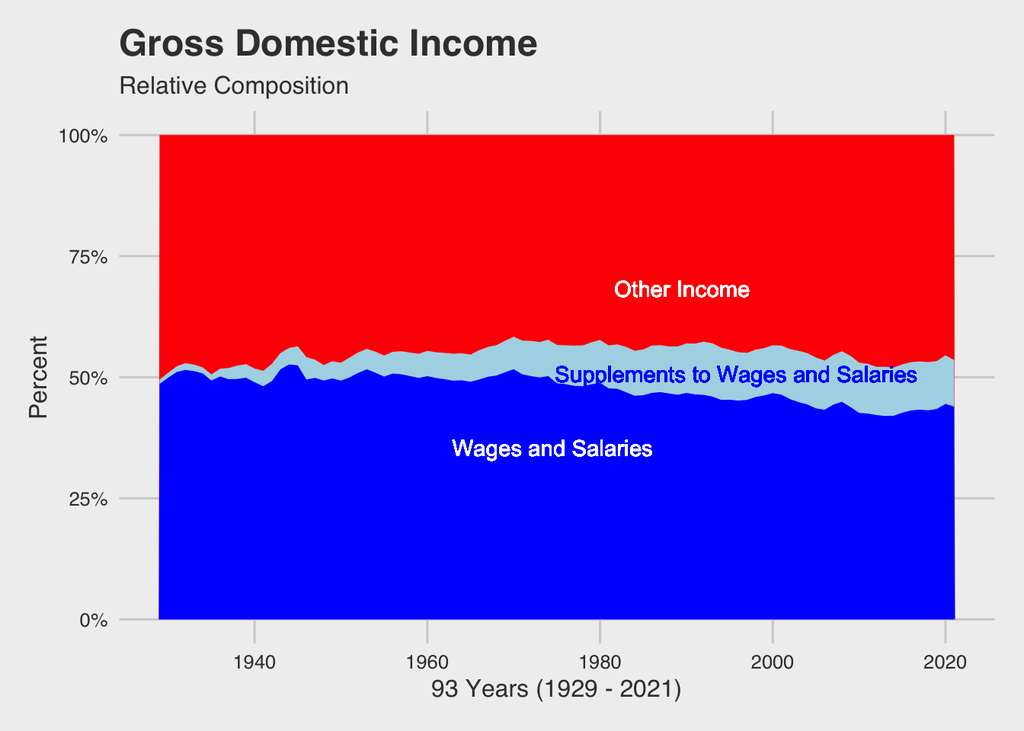

```r
ggplot(GDI, aes(x = observation_date)) +
  geom_area(aes(y = GDI/GDI, fill="red")) + #Non Compensation Income
  geom_area(aes(y = Total_Compensation/GDI, fill="lightblue")) +
  geom_area(aes(y = Wages/GDI, fill="blue")) +
  geom_text(aes(label = "Wages and Salaries", x = max(observation_date), y = .5), hjust = 2.5, vjust = 4.9, color = "white") +
  geom_text(aes(label = "Supplements to Wages and Salaries", x = max(observation_date), y = .49), hjust = 1.1, vjust = 0, color = "blue") +
  geom_text(aes(label = "Other Income", x = max(observation_date), y = .5), hjust = 2.5, vjust = -5, color = "white") +
  scale_fill_manual(values=c('blue', 'lightblue', 'red')) +
  guides(fill="none") +
  labs(title = "Gross Domestic Income",
       subtitle = "Relative Composition",
       x = "93 Years (1929 - 2021)",
       y = "Percent") + #Percent of Gross Domestic Income
  theme_fivethirtyeight() +
  theme(axis.title = element_text()) +
  scale_y_continuous(labels=scales::percent)
```

This warrants a closer look at the total compensation breakout.

I graph the total compensation and wages lines as a reference to show the gap. However, I want to focus on the path of the blue line: Supplements to Wages and Salaries as a percent of GDI. That line represents the monetary value of non-wage benefits and supplements provided by employer to their employees.

Here is what makes up Supplements to Wages and Salaries:

- Employer contributions to Social Security and other government-mandated social insurance programs
- Employer-provided health insurance
- Employer-provided housing and other benefits
- Employer-provided education and training
- Employer-provided relocation expenses.
- Employer-provided paid leave and vacation time
- Employer contributions to private pension plans
- Employer-provided bonuses and incentives

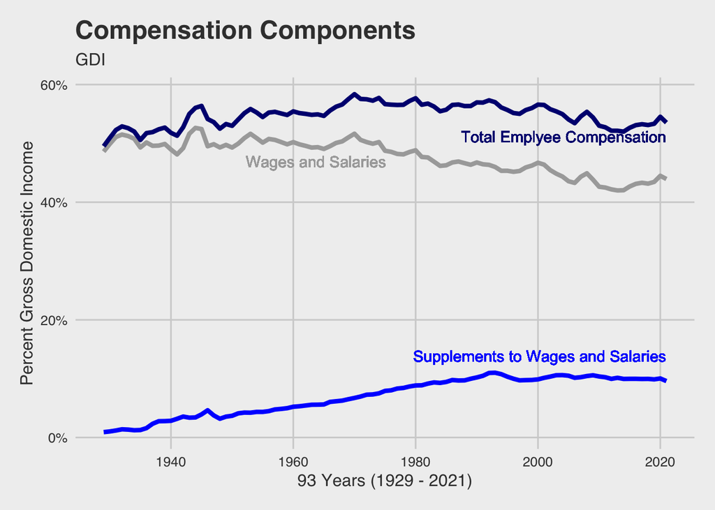

```r
ggplot(GDI, aes(x = observation_date)) +
  geom_line(linewidth=1.5, aes(y = Wage_GDI*100, colour = "darkgray")) +
  geom_line(linewidth=1.5, aes(y = Bonuses_GDI*100, colour = "blue")) +
  geom_line(linewidth=1.5, aes(y = Compensation_GDI*100, colour = "navy")) +
  geom_text(aes(label = "Wages and Salaries"), x = max(GDI$observation_date), y = max(GDI$Wage_GDI*100), hjust = 3, vjust = 3.5, color = "darkgray") +
  geom_text(aes(label = "Supplements to Wages and Salaries"), x = max(GDI$observation_date), y = max(GDI$Bonuses_GDI*100), hjust = 1, vjust = -1, color = "blue") +
  geom_text(aes(label = "Total Emplyee Compensation"), x = max(GDI$observation_date), y = max(GDI$Compensation_GDI*100), hjust = 1, vjust = 4.3, color = "navy") +
  scale_color_manual(values=c('blue', 'darkgray', 'navy')) +
  guides(color="none") +
  labs(title = "Compensation Components",
       subtitle = "GDI",
       x = "93 Years (1929 - 2021)",
       y = "Percent Gross Domestic Income") +
  theme_fivethirtyeight() +
  theme(axis.title = element_text()) +
  scale_y_continuous(labels=scales::unit_format(suffix = "%"))
```

Keeping in mind that we are looking at 93 years of data, I am going to attempt to maintain the high altitude of the analysis.

The data reflects that supplemental wages and salaries have been steadily increasing since 1929, up until the early 1990’s.

That increase can be attributed to:

- Government policies, such as the establishment of Social Security and other social insurance programs.
- Unions and collective bargaining have played a big role in negotiating for better benefits and working conditions for their members.
- Changing demographics increasing the number of older workers and retirees and the related employer contribution to private pension and health insurance.
- Changes in labor market, employers increasing benefits after WWII as they competed to attract and retain employees.
- Changes in business philosophy popularized by now discredited business thinkers like Milton Friedman increased business focus on incentive compensation.
- Changes in social norms have evolved the expectation of what constitutes a standard benefits package.

These factors led to a steady increase in the proportion of total compensation that is made up of supplements such as benefits, in the GDI calculation. But why did that increasing trend plateau around the 1990’s?

Several factors aligned, tilting the scales in favor of the employer’s interest and suppressing employee leverage and pay.

- The fall of the Soviet Union and the collapse of the communist bloc with Central European countries joining EU, in conjunction with the global dominance of the Washington Consensus, led to a period of economic stability and growth, and facilitated the expansion of global trade and the free movement of capital. We called this **globalization**.
- New technologies and globalization of trade were increasing interconnectedness of the world economy and led to acceptance of **outsourcing** as a business practice. There wasn’t a pivotal point when this practice of focusing on core competencies and outsourcing everything else to cut costs gained momentum, but the trend accelerated in the 1990s and 2000s. This shift in business philosophy was promoted by key Business Schools. The 1990 Harvard Business Review (HBR) article where C.K. Prahalad & Gary Hamel coined the term “Core Competency” became one of the most read articles of HBR.
- You might wonder, how did the corporate owners, the investors, react to the Board of Directors’ endorsement of the management embrace of globalization. In the 1970’s and 80’s the Corporate Governance philosophy of investors and shareholders shifted from engagement with the management team to **focus on trading** and letting the market handle poor management through stock price. This coincided with corporate transfer of risk from corporations to the worker’s as Defined Benefits pension plans were retired in favor of Defined Contribution pension plans. The net result is that owners do not ask management for explanations when mismanagement occurs, they just sell the stock. This translates in practice as **reduction in corporate board oversight**.
- You might wonder, how do the management teams react to more lax corporate board oversight? They embrace the change. In 2021 CEOs were paid 399 times as much as the typical worker gets paid. In 1965 CEOs were paid 20 times what the average worker made. **The CEO pay has increased by 1,460% since 1978**. [Look at the graph, the timing of the increase coincided with rise of globalization in the 90’s.](https://www.marketwatch.com/story/average-ceo-pay-rose-11-in-2021-and-is-now-399-times-more-than-the-typical-workers-wages-11664895973) The average CEO was paid $27.8 million in 2021.
- This brings us back to the graph. Economic stability increased global trade, as corporate governance was being relaxed, setting the stage for massive executive pay increases. But we were discussing the reasons for the supplemental wages and salaries plateau around 1990’s. Yes, this plateau is that much more vexing if you consider what happened to the employer-provided bonuses and incentives at that time.
- Around the 1990’s and 2000’s it became popular for some of the CEO’s to take a symbolic salary of $1 per year. Intuitively, this might feel like a huge salary cut but fear not. The point was to shift executive compensation to reliance on performance incentives and bonuses. The now discredited architect of that economic philosophy was Milton Friedman. In 1970 he published an article entitled: “The Social Responsibility of Business is to Increase its Profits.” Friedman argued that the only social responsibility of a business is to increase profits for its shareholders, and that any other goals, such as social or environmental responsibility, would be a distraction from that primary goal. This was adopted by the Boards of Directors as the concept of maximizing shareholder value. This concept was reinforced by other influential figures in the business world, such as management theorist Peter Drucker who argued that a focus on **maximizing shareholder value** would lead to better decision making and improved (*financial*) performance for the company.
- The *improved* decisions of management now incentivized financially to maximize shareholder value and aided by globalization, made it easy to **push back on unionization**. Corporations were hiring anti-union consultants and engaging in legal challenges to prevent employees from forming unions. The success of those tactics is manifested in the supplemental wages and salaries line plateau around 1990’s.
- The plateau is also an indicator of several negative consequences of globalization, increased competition, job loss, and increase in inequality. Many people felt left behind by the process and that led to a political backlash in many countries, but that is a topic for a very different analysis.

The points above are within the mainstream current of discussing compensation inequality. However, my first graph of GDI shows this is only the total compensation, around 50% of the income. What is the other 50%.

### Opportunity

Welcome to the world of non-compensation income.

GDI is not intended to be a measure of how the working-class fares in the economy. Instead, it is a measure of the total income generated in the economy, regardless of how it is distributed.

When we spend money on finished goods and services, that spending in aggregate is the gross domestic income. It is the flip side of the value of the product measured by GDP. About half of that income is paid to workers as compensation. The other half is comprised of income earned by businesses, consumption of fixed capital, and taxes on production and imports.

We will make it our business to unpack and understand income earned by business. The most common form of business in the US is a corporation. A corporation is a business entity that is owned by its shareholder(s), who elect a board of directors to oversee the organization’s activities as they are managed by the management, generally hired professional management. As we discussed in context of total compensation, the theory and the practice may differ. It is in that income stream where we will look for opportunities.

The graph bellow shows Total non-compensation income and the income earned by business. The gap is comprised of the before mentioned consumption of fixed capital, and taxes on production and imports. I draw a thin gray line to reflect the relative size of the items.

Just briefly, for the curious at heart, let’s address those two items we will ignore before moving on.

- Taxes on production and imports. This line item is included in the GDI calculation because it represents income that is generated by the domestic economy, regardless of who earns it. In other words, even though taxes on production and imports may be collected by the government and not directly accrue to households or businesses, they are still considered as part of the economy’s income as they are used to fund public goods and services, which in turn can have an impact on the overall economic activity.
- Consumption of fixed capital. Here we dive into the domain of accounting and tax law. Tax law defines how businesses are allowed to depreciate major capital-intensive asset used in the production, this means buildings, machinery, computers and so on. Accounting principles ask that we match the decline in value of those fixed assets that result from normal use, wear and tear and obsolescence with the period in which they are used. Given that everything wares out and we need to replace it, depreciation in aggregate is a good proxy for what people spend in that period on capital assets.

Here is graph.

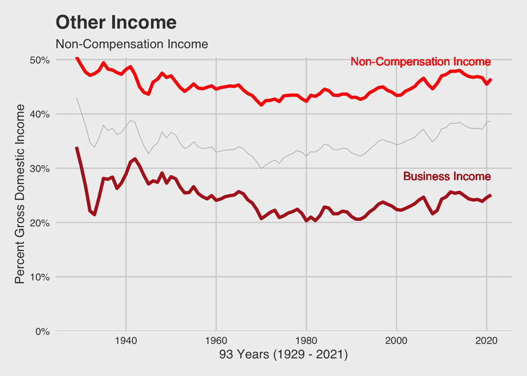

```r
ggplot(GDI, aes(x = observation_date)) +
  geom_line(linewidth=1.5, aes(y = (1-Compensation_GDI)*100, colour = "red")) + # Non-Comp Income
  geom_line(linewidth=0.35, aes(y = (Depreciation/GDI+Business_GDI)*100, colour = "gray")) + # FYI - Thin line of Depreciation
  geom_line(linewidth=1.5, aes(y = Business_GDI*100, colour = "firebrick")) + # Business Income
  geom_text(aes(label = "Business Income"), x = max(GDI$observation_date), y = max(GDI$Business_GDI*100), hjust = 1, vjust = 4, color = "firebrick") +
  geom_text(aes(label = "Non-Compensation Income"), x = max(GDI$observation_date), y = max(GDI$NonComp_GDI*100), hjust = 1, vjust = 1, color = "red") +
  scale_color_manual(values=c('firebrick', 'gray', 'red')) +
  guides(color="none") +
  labs(title = "Other Income",
       subtitle = "Non-Compensation Income",
       x = "93 Years (1929 - 2021)",
       y = "Percent Gross Domestic Income") +
  theme_fivethirtyeight() +
  theme(axis.title = element_text()) +
  scale_y_continuous(expand = c(0, 0), limits = c(0, NA), labels=scales::unit_format(suffix = "%"))
```

Now we can dive into the components of income derived by business as it appears on GDI. If you think that is a small sliver of income, consider that in 2021 we are talking about $5.9 Trillion dollars. We are definitively still painting with big brush strokes.

Five major components of income derived by business:

- **Retained Earnings**. The GDI line item reads: “Undistributed corporate profits with inventory valuation and capital consumption adjustments.” This is a measure of the portion of profits generated by incorporated businesses that are not distributed as dividends to shareholders, in other words, retained earnings. This is the money a company retains for reinvestment into the business. If the company grows at the time of sale, the income is recognized as capital gains.
- **Dividends**. This means a portion of corporate profits not reinvested back into the business but disbursed to the shareholders. Note that paying dividends is not an expense. It is the division of after-tax profits among shareholders.
- **Rental Income**. The income earned by individuals and households from the rental of their property or other assets.
- **Interest Payments**. This is the income received by domestic industries in the form of interest payments on loans, bonds, and other financial instruments. This includes the interest portion of your mortgage payment, interest on the balance of your credit card or the coupon interest payment received on bonds.
- **Small Business**. The income earned by self-employed individuals and unincorporated businesses, such as small businesses and farmers. It is also known as “gross mixed income” (GMI), as it combines both capital and labor income.

Here is the graph.

[figure not shown]

```r
ggplot(GDI, aes(x = observation_date)) +
  geom_area(aes(y = SmallBusiness_BIZ+Interest_Income_BIZ+Retained_Earnings_BIZ +Dividents_BIZ+Rentals_BIZ, fill="firebrick")) +  #1
  geom_area(aes(y = SmallBusiness_BIZ+Interest_Income_BIZ+Retained_Earnings_BIZ +Dividents_BIZ, fill="goldenrod")) +                  #2
  geom_area(aes(y = SmallBusiness_BIZ+Interest_Income_BIZ+Retained_Earnings_BIZ, fill="deeppink1")) +                                      #3
  geom_area(aes(y = SmallBusiness_BIZ+Interest_Income_BIZ, fill="orangered")) +                                                  #4
  geom_area(aes(y = SmallBusiness_BIZ, fill="chocolate4")) +
  geom_text(aes(label = "Retained Earnings", x = max(observation_date), y = .5), hjust = 3.2, vjust = -8, color = "yellow") +
  geom_text(aes(label = "Dividents", x = max(observation_date), y = .5), hjust = 2, vjust = -6.5, color = "yellow") + #5
  geom_text(aes(label = "Rental Income", x = max(observation_date), y = .5), hjust = 4.3, vjust = -1, color = "gold") +
  geom_text(aes(label = "Interest Payments", x = max(observation_date), y = .5), hjust = 1.6, vjust = 2.8, color = "gold") +
  geom_text(aes(label = "Small Business", x = max(observation_date), y = .5), hjust = 1.5, vjust = 11, color = "gold") +
  scale_fill_manual(values=c('chocolate4', 'orangered', 'deeppink1', 'goldenrod', 'firebrick')) +
  guides(fill="none") +
  labs(title = "Business Income Composition",
       subtitle = "Business Income",
       x = "93 Years (1929 - 2021)",
       y = "Percent of Business Income") +
  theme_fivethirtyeight() +
  theme(axis.title = element_text()) +
  scale_y_continuous(labels=scales::percent)
```

I just want to remind everyone that we are talking about real money. For 2021 the dividends were $1.4 Trillion, the Interest income was $0.9 Trillion, rental income was $0.7 Trillion and the retained earnings were $569 Billion.

Let us step back for a minute to grasp the context of this graph.

We are looking at the detail of income attributable to business, about 25% of Gross Domestic Income, income other than the actual compensation for labor that people think of as income. Those are the details discussed on Bloomberg but not truly explained on mainstream media. And there might be a good reason for that, as this detail is currently irrelevant for most people.

Based on 2022 Federal Reserve Data [53% of corporate stocks is owned by 1% of the US population.](https://www.fool.com/research/how-many-americans-own-stock/) This is $16.8 Trillion worth of stocks. The value increases to $28 Trillion when we look at stock ownership of the top 10% of the population. That is 88.6% of the stock.

While compensation inequality receives significant attention, the distribution of non-compensation income has a far more significant impact on overall wealth inequality and contributes to the persistence of such inequality across generations.

### Addressable Problem

Understanding both compensation and non-compensation income is important for developing a comprehensive understanding of the total income and wealth inequality in an economy. It is only with such insight that we can start to think about opportunities to address the problem.

If perchance you do not believe this to be a problem, spend a day listening to the news. Or drive into the countryside and talk to people who are attracted to extremist ideologies. Their cynicism isn’t about the possibility of the future. It is in their equitable share in it. This is an addressable problem.

### There is Precedent

##### Policy change:

Go anywhere in the USA, to a big or small city, east coast or west coast, or the heartland, and walk on any sidewalk, step into any building.

For anybody who remembers using a wheelchair or other mobility device the 1980’s the landscape is unrecognizable. The cities and buildings today are accessible.

A monumental task was accomplished in 1990 with the passage of [The Americans with Disabilities Act (ADA)](https://www.ada.gov/topics/intro-to-ada/). The ADA required that all new construction and any alterations to existing facilities be made accessible to people with disabilities. One of the requirements of the ADA is that sidewalks have curb ramps or other sloped areas at intersections and crosswalks, to allow people using wheelchairs or other mobility devices to safely navigate the sidewalk.

##### Business Innovation:

Before 1975 there were many obstacles to owning a diversified stock portfolio. The invention of an index mutual fund made investing easier and lowered the cost for the average investor. Today, [Vanguard](https://investor.vanguard.com/corporate-portal/), the firm founded by [John Bogle](https://en.wikipedia.org/wiki/John_C._Bogle) is one of the largest and most well-known investment companies in the world.

Since the 1970’s, we have seen other innovations that made investing more accessible: Discount brokers, On-line brokers, Exchange Traded Funds (ETF), and Robo-Advisors.

##### The Reality we Create:

Over the course of history, we have taken steps towards improving the condition of human life using policy changes and innovation as demonstrated above. This is a long history. The accessibility movement has common roots with the civil rights movement and the Civil Rights Act of 1964. Before John Boggle could dream of a stock index fund, the East India Company had to be incorporated in 1600 as a first stock corporation and set the stage for formation of the stock market.

The intent of this analysis is to highlight the biggest curbs or steps in inequality where we need ramps or other slopped paths to make our future more equitable.

##### Current Opportunities:

**Rental Income:** Home ownership is the biggest source of wealth generation for the general population. The government policy that enabled this accessibility was the government creation of secondary market for mortgage-backed securities and thus, giving the general population access to leverage.

Companies such as [Divvy Homes](https://www.divvyhomes.com/) make the transition from renting to home ownership more accessible through their innovation with fractional homeownership and rent-to-own model.

**Interest Income:** The bond market, or the credit market, is more than twice the size of the stock market in the USA. However, the bond market does not have anywhere near the accessibility as the stock market. The average bond trade exceeds $500,000, a purchase usually made by institutional investors.

The peer-to-peer lending industry set out to revolutionize general population access to interest income. In 2006, [LendingClub](https://www.lendingclub.com) enabled borrowers to create unsecured personal loans between $1,000 and $40,000. That business model did not last. The company still exists; however the source of funds has been taken over by institutional investors.

**Dividends:** To earn dividends, you need to own stocks. For many the costs are still prohibitive. One innovation making stock ownership more accessible is [fractional share ownership](https://www.forbes.com/advisor/investing/fractional-shares/). In the past, investors generally would end up with fractional shares only after a stock split, since brokers only allowed the purchase of full shares. Today, many brokerages allow you to buy $15 of apple and $20 of Alphabet even though the individual stocks are over $100 each.

**Retained Earnings:** The accountability and responsibility of corporations and the implications of corporate government changes are perhaps the most overlooked sources of opportunity. The technology that facilitates a public record of transactions, blockchain, has potential to revolutionize corporate governance and the ability of stakeholders to collaborate.

Where else do you see opportunity in increasing the general populations access to income?

# Next

Having lived through three recessions and in different economies around the world, I am curious about the economic systems impact on the human condition. Additionally, having lived through a divorce, I am finding myself wondering if the economic conditions we are creating are traumatic to the population at large.

Additional analysis that would be helpful.

- Understand platformization and how the increasingly dominant new business model transforms the fundamentals of the marketplace, the nature of work, and thus the nature of capitalism as we know it.
- Analysis of UBI as a vector of Domestic Abuse prevention and thus an economic stimulant.
- Analysis of impact of cooperative corporation (co-op) structure on the wealth and welfare of the corporate stakeholders. This would have never crossed my mind if I did not embrace the Minnesotan in me. FYI, Land O’Lakes is a Minnesota based member-owned agricultural cooperative.
- Analysis of impact of proxy voting on corporate decisions over time. It would be ideal if data from the 70’s and 80’s was available to juxtapose with the role and service of today’s Proxy advisory firms.
- Fractional share adoption and the impact on people’s desire and ability to manage their investment portfolios.

When you look at the graph of the Business Income Composition it looks like a choppy water of ocean. This is not a metaphor. Those are turbulent, unpredictable, up and down historical income streams. It is easier to navigate such income volatility with a big balance sheet. With enough innovation, the right policies, and through the magic of compounding, hopefully, we can help more people build up their balance sheets and participate fully in the non-compensation income.

This analysis raised a million more questions than it answers. Hope you enjoyed it as much as I did.

Note: *The image link from the home page to this analysis is “Hopeless”, by Roy Lichtenstein, painted a year before the Civil Rights Act of 1964. My belief is that just as the Civil Rights Act of 1964 was a major step in the direction of racial equality, we are on the verge of innovation that will be a major step in direction of income equality.*